# Prediction Tunning

Gustavo Monteiro

November 2, 2018

> The database that will be used in this study consists of data on the votes that candidates for the Federal Chamber of Deputies received in the years 2006 and 2010 (source: http://www.tse.jus.br), as well as information on campaigning, party, schooling, … of them.

## Loading data.

```r
train <- read.csv("train.csv")
test <- read.csv("test.csv")
```

## Removing categoric variables.

```r
train <- train %>% select(-nome, -uf, -estado_civil,
                          -partido, -ocupacao,-ano,
                          -cargo,-grau,-sexo,
                          -sequencial_candidato)
```

> for this we will compare 3 types of regression, ridge, lasso and knn, which will be executed follow.

## Ridge regression.

```r
set.seed(1)

fitControl <- trainControl(method = "repeatedcv", number = 10, repeats = 10)
lambdaGrid <- expand.grid(lambda = 10^seq(10, -2, length=100))

# modelo utilizando regressão ridge
model <- train(votos ~ .,
               data = train,
               method = "ridge",
               trControl = fitControl,
               preProcess = c('scale', 'center'),
               tuneGrid = lambdaGrid,
               na.action = na.omit)
model
```

```
## Ridge Regression
##
## 7476 samples
##   13 predictors
##
## Pre-processing: scaled (13), centered (13)
## Resampling: Cross-Validated (10 fold, repeated 10 times)
## Summary of sample sizes: 6729, 6729, 6728, 6729, 6728, 6729, ...
## Resampling results across tuning parameters:
##
##   lambda        RMSE       Rsquared   MAE
##   1.000000e-02   37992.18  0.4029785  16917.96
##   1.321941e-02   38028.99  0.4024646  16918.64
##   1.747528e-02   38074.06  0.4018611  16916.32
##   2.310130e-02   38127.82  0.4011888  16909.12
##   3.053856e-02   38191.23  0.4004698  16894.77
##   4.037017e-02   38266.21  0.3997206  16870.82
##   5.336699e-02   38356.25  0.3989470  16834.55
##   7.054802e-02   38466.99  0.3981398  16782.72
##   9.326033e-02   38607.21  0.3972726  16710.82
##   1.232847e-01   38790.02  0.3963037  16615.54
##   1.629751e-01   39034.91  0.3951806  16492.44
##   2.154435e-01   39370.79  0.3938494  16335.49
##   2.848036e-01   39840.63  0.3922681  16139.24
##   3.764936e-01   40507.88  0.3904209  15905.99
##   4.977024e-01   41464.25  0.3883290  15638.74
##   6.579332e-01   42836.95  0.3860532  15361.10
##   8.697490e-01   44790.93  0.3836857  15154.35
##   1.149757e+00   47519.77  0.3813346  15343.81
##   1.519911e+00   51219.24  0.3791034  16896.20
##   2.009233e+00   56044.17  0.3770752  19500.74
##   2.656088e+00   62058.68  0.3753024  22802.30
##   3.511192e+00   69197.66  0.3738051  26690.85
##   4.641589e+00   77254.86  0.3725763  31020.24
##   6.135907e+00   85904.66  0.3715908  35632.55
##   8.111308e+00   94752.21  0.3708140  40321.60
##   1.072267e+01  103398.10  0.3702096  44886.85
##   1.417474e+01  111498.64  0.3697435  49143.23
##   1.873817e+01  118806.32  0.3693863  52969.71
##   2.477076e+01  125183.55  0.3691137  56301.25
```

[output cut: 59 more lines]

```
##   4.641589e+08  151645.04  0.3682555  70106.81
##   6.135907e+08  151645.04  0.3682555  70106.81
##   8.111308e+08  151645.04  0.3682555  70106.81
##   1.072267e+09  151645.04  0.3682555  70106.81
##   1.417474e+09  151645.04  0.3682555  70106.81
##   1.873817e+09  151645.04  0.3682555  70106.81
##   2.477076e+09  151645.04  0.3682555  70106.81
##   3.274549e+09  151645.04  0.3682555  70106.81
##   4.328761e+09  151645.04  0.3682555  70106.81
##   5.722368e+09  151645.04  0.3682555  70106.81
##   7.564633e+09  151645.04  0.3682555  70106.81
##   1.000000e+10  151645.04  0.3682555  70106.81
##
## RMSE was used to select the optimal model using the smallest value.
## The final value used for the model was lambda = 0.01.
```

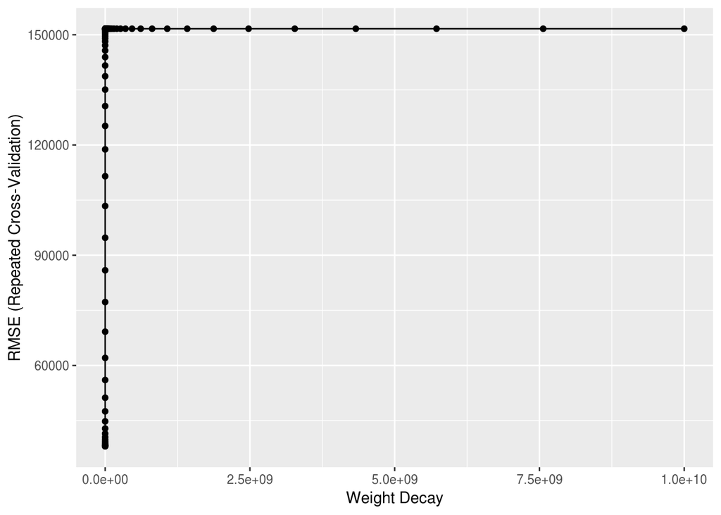

```r
ggplot(model)
```

> Variable importance for ridge regression

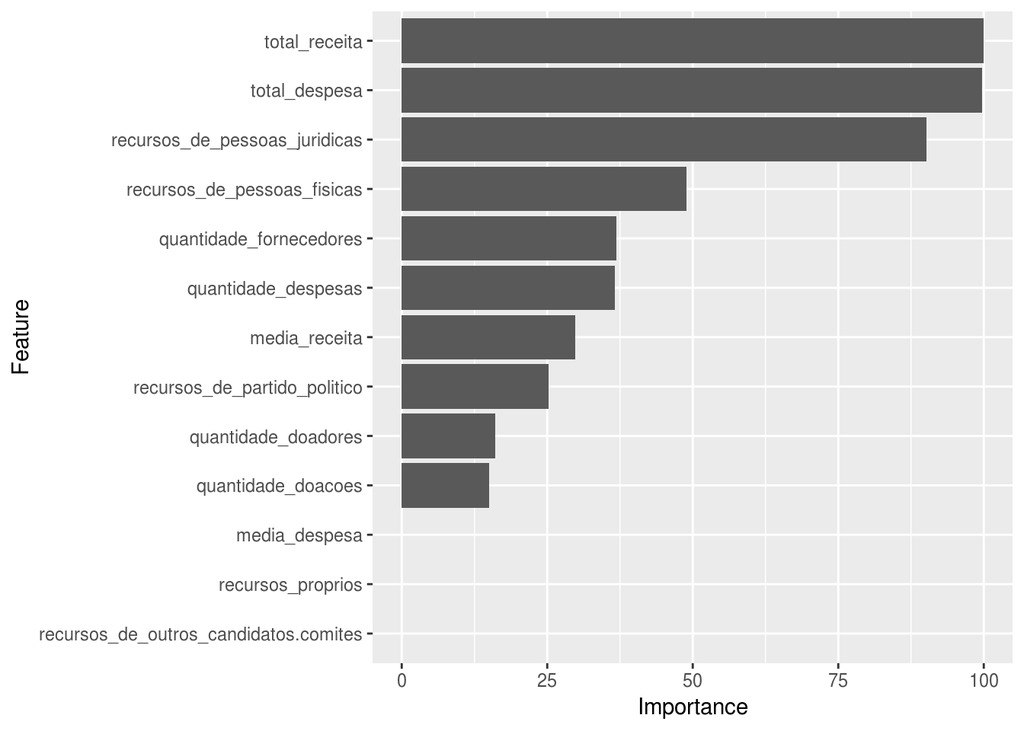

```r
ggplot(varImp(model))
```

## Lasso regression.

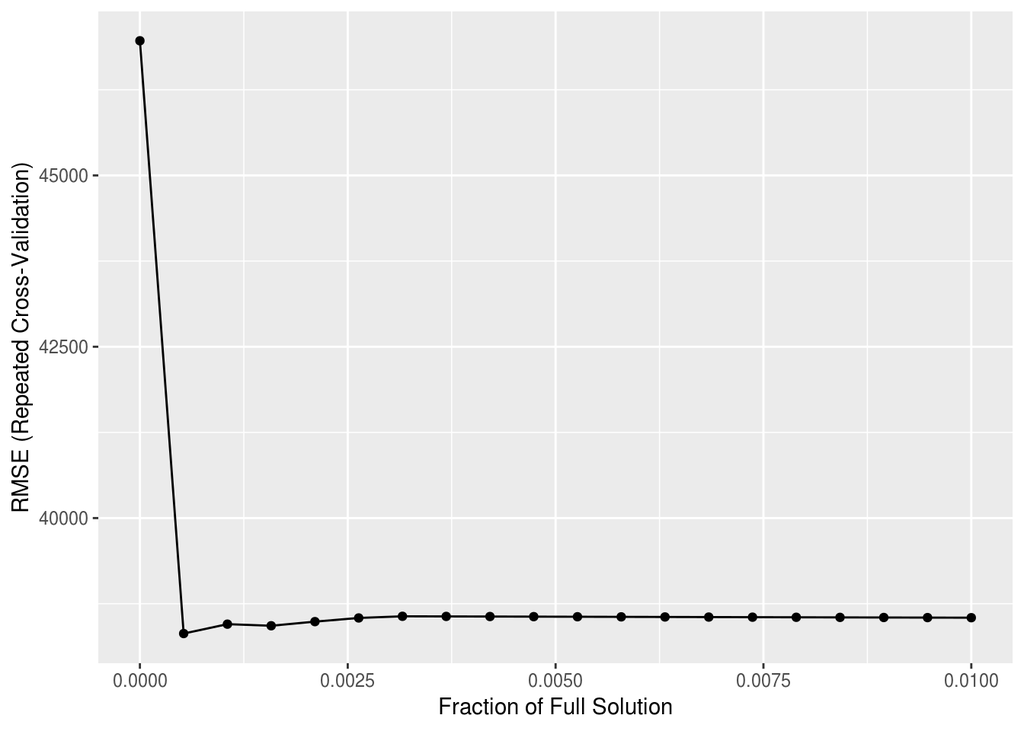

```r
set.seed(1)
lambda <- expand.grid(fraction = seq(0.01, 10^-8, length=20))
model_lasso <- train(votos ~ .,
                     data = train,
                     method = "lasso",
                     tuneGrid = lambda,
                     preProc = c("center", "scale"),
                     trControl = fitControl)
ggplot(model_lasso)
```

```r
model_lasso
```

```
## The lasso
##
## 7476 samples
##   13 predictors
##
## Pre-processing: centered (13), scaled (13)
## Resampling: Cross-Validated (10 fold, repeated 10 times)
## Summary of sample sizes: 6729, 6729, 6728, 6729, 6728, 6729, ...
## Resampling results across tuning parameters:
##
##   fraction      RMSE      Rsquared   MAE
##   0.0000000100  46964.90  0.4034546  28624.33
##   0.0005263253  38315.10  0.3960888  19639.19
##   0.0010526405  38452.07  0.4009972  17766.75
##   0.0015789558  38428.58  0.4039639  17536.65
##   0.0021052711  38488.95  0.4029602  17512.22
##   0.0026315863  38542.52  0.4020506  17506.00
##   0.0031579016  38566.62  0.4016407  17504.58
##   0.0036842168  38564.98  0.4016362  17503.38
##   0.0042105321  38563.35  0.4016316  17502.18
##   0.0047368474  38561.73  0.4016267  17500.98
##   0.0052631626  38560.12  0.4016214  17499.77
##   0.0057894779  38558.53  0.4016158  17498.57
##   0.0063157932  38556.95  0.4016098  17497.37
##   0.0068421084  38555.39  0.4016036  17496.17
##   0.0073684237  38553.84  0.4015970  17494.98
##   0.0078947389  38552.30  0.4015901  17493.79
##   0.0084210542  38550.78  0.4015828  17492.59
##   0.0089473695  38549.28  0.4015753  17491.40
##   0.0094736847  38547.79  0.4015674  17490.21
##   0.0100000000  38546.31  0.4015592  17489.02
##
## RMSE was used to select the optimal model using the smallest value.
## The final value used for the model was fraction = 0.0005263253.
```

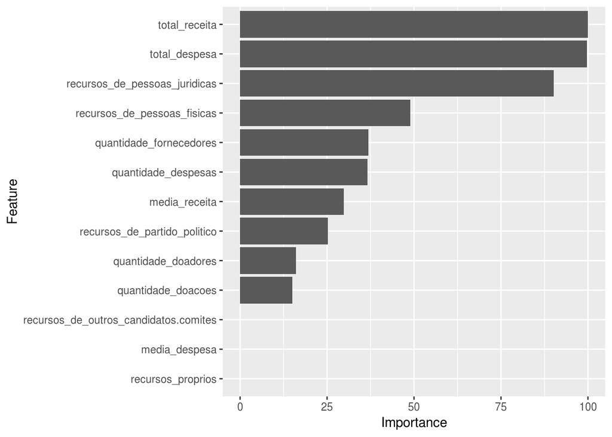

```r
ggplot(varImp(model_lasso))
```

## Knn regression.

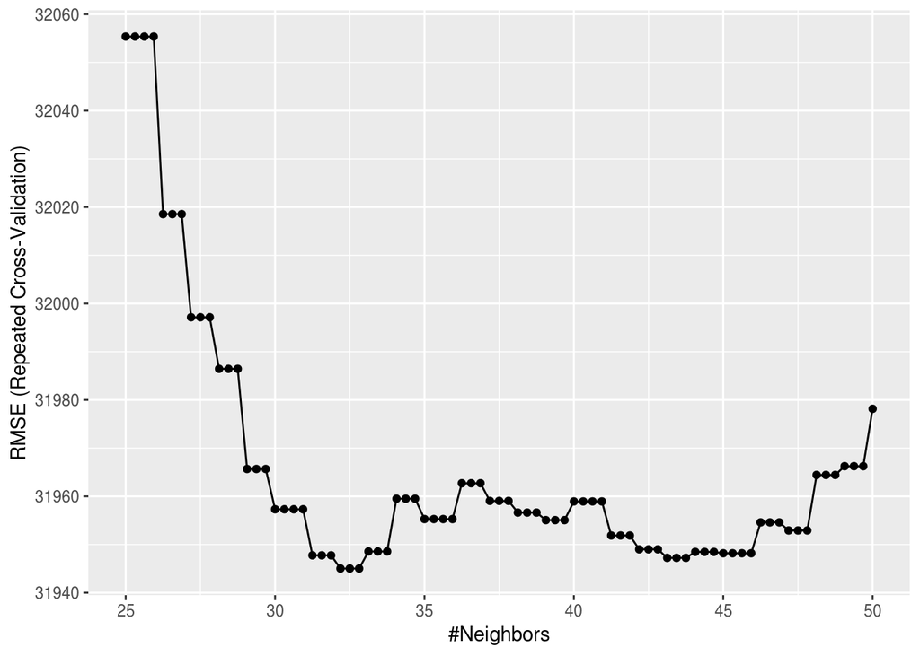

```r
k <- expand.grid(k = seq(25, 50, length=81))
model_knn <- train(votos ~ .,
                     data = train,
                     method = "knn",
                     tuneGrid = k,
                     preProc = c("center", "scale"),
                     trControl = fitControl)
ggplot(model_knn)
```

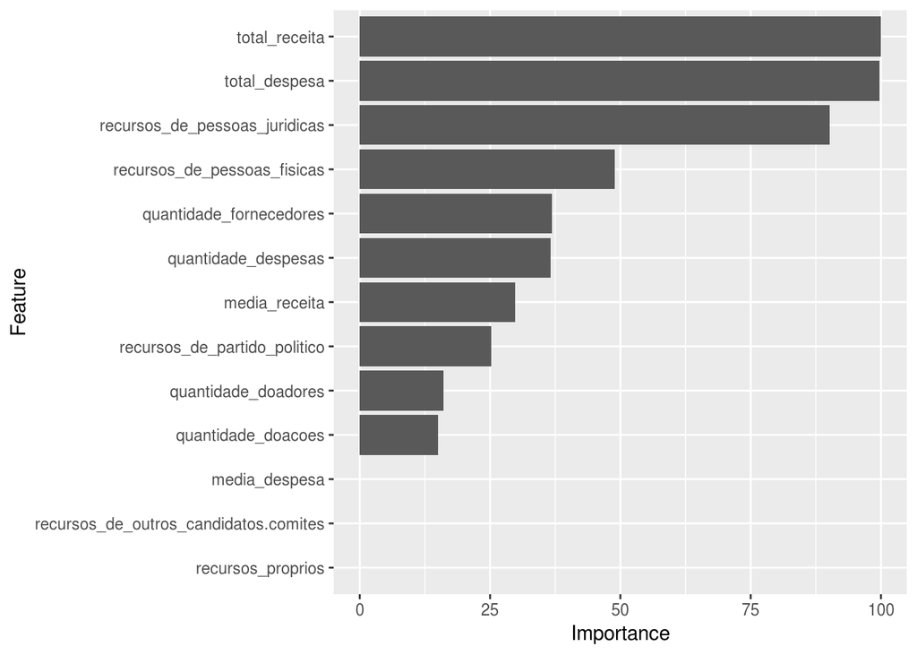

```r
ggplot(varImp(model_knn))
```

## Results

For the tests done, we see that in all models the definition of which predictors are most useful basically does not change, what was expected, having only some eventual change of position in the ranking, but in all defining the most significant variables as `total_receita`, `total_despeza`, `resources_of_personal_juridicas`.

Following a model using knn will be created, which proved to be the one with the best results and using only the best predictors, this prediction model will be used for prediction of votes over the 2014 elections data in Brazil

```r
model_knn_topper <- train(votos ~ total_receita * total_despesa * recursos_de_pessoas_juridicas,
                     data = train,
                     method = "knn",
                     tuneGrid = k,
                     preProc = c("center", "scale"),
                     trControl = fitControl)
```

## Generation predictions for test dataframe to submit to Kaggle, to related [competition](https://www.kaggle.com/c/ufcg-cdp-20182).

NOTE: for a delay in sending, the following prediction does not appear in the ranking, but reached a score of 30888.82009, which would fit as the third place in the public ranking had it been sent on time.

```r
prediction <- predict(model_knn_topper, test)
data_out <- data.frame(ID = test$sequencial_candidato, votos = prediction)
data_out$ID <-as.character(data_out$ID)
data_out %>% write_csv(path = "response.csv")
prediction
```

[output not shown]

[output cut: 905 more lines]